# 201.11. CcdVisit table

For the Rubin Science Platform at data.lsst.cloud.  
Data Release: [Data Preview 1](https://dp1.lsst.io/)  
Container Size: large  
LSST Science Pipelines version: r29.2.0  
Last verified to run: 2025-09-02  
Repository: github.com/lsst/tutorial-notebooks

**Learning objective:** To understand the contents of the `CcdVisit` table and how to access it.

**LSST data products:** `CcdVisit`

**Packages:** `lsst.rsp`, `lsst.daf.butler`

**Credit:** Originally developed by the Rubin Community Science team. Please consider acknowledging them if this notebook is used for the preparation of journal articles, software releases, or other notebooks.

**Get Support:** Everyone is encouraged to ask questions or raise issues in the [Support Category](https://community.lsst.org/c/support) of the Rubin Community Forum. Rubin staff will respond to all questions posted there.

## 1. Introduction

A `CcdVisit` refers to an observation of the sky with an individual detector of the camera.

The `CcdVisit` table contains data about the individual observations for every detector of a `Visit`, such as the coordinates, date, time, filter, camera rotation, and exposure time. It also contains image characterization data for the associated `visit_image` (the processed, calibrated pixel data for one detector), such as the point-spread function (PSF) size, seeing, sky background, and zeropoint.

The contents of the `CcdVisit` table are associated with the individual detectors of the camera (9 for LSSTComCam). By contrast, the `Visit` contains data associated with the boresight of the entire focal plane.

- TAP table name: `dp1.CcdVisit`
- Butler table name: `visit_detector_table`
- columns: 50
- rows: 16071

**Related tutorials:** The tutorial for the `Visit` table is also in this series. The TAP and Butler data access services are demonstrated in the 100-level "How to" tutorials.

### 1.1. Import packages

Import standard python packages `re`, `numpy`, `matplotlib`, and `astropy`.

From the `lsst` package, import modules for the TAP service and the Butler.

```python
import re
import numpy as np
import matplotlib.pyplot as plt
from lsst.rsp import get_tap_service
from lsst.daf.butler import Butler
from lsst.utils.plotting import (get_multiband_plot_colors,
                                 get_multiband_plot_symbols)
```

### 1.2. Define parameters and functions

Create an instance of the TAP service, and assert that it exists.

```python
service = get_tap_service("tap")
assert service is not None
```

Create an instance of the Rubin data Butler, and assert that it exists.

```python
butler = Butler('dp1', collections="LSSTComCam/DP1")
assert butler is not None
```

Define the colors and symbols to represent the LSST filters in plots.

```python
filter_names = ['u', 'g', 'r', 'i', 'z', 'y']
filter_colors = get_multiband_plot_colors()
filter_symbols = get_multiband_plot_symbols()
```

## 2. Schema (columns)

To browse the table schema visit the [Rubin schema browser](https://sdm-schemas.lsst.io/), or use the TAP service via the Portal Aspect or as demonstrated in Section 2.1.

### 2.1. Retrieve table schema

To retrieve the table schema, define a query for the schema columns of the `CcdVisit` table and run the query job.

```python
query = "SELECT column_name, datatype, description, unit " \
        "FROM tap_schema.columns " \
        "WHERE table_name = 'dp1.CcdVisit'"
job = service.submit_job(query)
job.run()
job.wait(phases=['COMPLETED', 'ERROR'])
print('Job phase is', job.phase)
if job.phase == 'ERROR':
    job.raise_if_error()
```

```
Job phase is COMPLETED
```

Retrieve the query results and display them as an `astropy` table with the `to_table()` attribute.

```python
assert job.phase == 'COMPLETED'
results = job.fetch_result().to_table()
assert len(results) == 50
results
```

*Table length=50*

| column_name str64 | datatype str64 | description str512 | unit str64 |
| --- | --- | --- | --- |
| astromOffsetMean | double | Mean offset of astrometric calibration matches (arcsec) | arcsec |
| astromOffsetStd | double | Standard deviation of offsets of astrometric calibration matches (arcsec) | arcsec |
| band | char | Name of the band used to take the visit where this source was measured. Abstract filter that is not associated with a particular instrument. |  |
| ccdVisitId | long | Primary key (unique identifier). |  |
| darkTime | double | Average dark current accumulation time, accurate to 10ms. | s |
| dec | double | Declination of Ccd center. | deg |
| detector | long | Detector ID. A detector associated with a particular instrument (not an observation of that detector). |  |
| effTime | double | Effective time metric | s |
| effTimePsfSigmaScale | double | Effective time metric -- PSF size component |  |
| effTimeSkyBgScale | double | Effective time metric -- Sky background component |  |
| effTimeZeroPointScale | double | Effective time metric -- Throughput component |  |
| expMidpt | char | Midpoint time for exposure at the fiducial center of the focal plane array. TAI, accurate to 10ms. |  |
| expMidptMJD | double | Midpoint time for exposure at the fiducial center of the focal plane array in MJD. TAI, accurate to 10ms. | d |
| expTime | double | Spatially-averaged duration of visit, accurate to 10ms. | s |
| llcdec | double | Declination of lower left corner. | deg |
| llcra | double | Right Ascension of lower left corner. | deg |
| lrcdec | double | Declination of lower right corner. | deg |
| lrcra | double | Right Ascension of lower right corner. | deg |
| magLim | double | 5-sigma limiting magnitude | mag |
| ... | ... | ... | ... |
| psfStarDeltaE2Scatter | double | Scatter (via MAD) of E2 residual (starE2 - psfE2) for psf stars |  |
| psfStarDeltaSizeMedian | double | Median size residual (starSize - psfSize) for psf stars (pixel) | pixel |
| psfStarDeltaSizeScatter | double | Scatter (via MAD) of size residual (starSize - psfSize) for stars (pixel) | pixel |
| psfStarScaledDeltaSizeScatter | double | Scatter (via MAD) of size residual scaled by median size squared |  |
| psfTraceRadiusDelta | double | Delta (max - min) of model psf trace radius values evaluated on a grid of unmasked pixels (pixel) | pixel |
| ra | double | Right Ascension of Ccd center. | deg |
| seeing | double | Mean measured FWHM of the PSF. | arcsec |
| skyBg | float | Average sky background. | adu |
| skyNoise | float | RMS noise of the sky background. | adu |
| skyRotation | double | Sky rotation angle. | deg |
| ulcdec | double | Declination of upper left corner. | deg |
| ulcra | double | Right Ascension of upper left corner. | deg |
| urcdec | double | Declination of upper right corner. | deg |
| urcra | double | Right Ascension of upper right corner. | deg |
| visitId | long | Reference to the corresponding entry in the Visit table. |  |
| xSize | long | Number of columns in the image. | pixel |
| ySize | long | Number of rows in the image. | pixel |
| zenithDistance | float | Zenith distance at observation mid-point. | deg |
| zeroPoint | float | Zero-point for the Ccd, estimated at Ccd center. | mag |

The table displayed above has been truncated.

Option to print every column name as a list.

```python
# for col in results['column_name']:
#     print(col)
```

Option to use the regular expressions package `re` to search for columns for which the description contains the string `temp`.

```python
# temp = 'time'
# temp = 'corner'
# temp = 'psf'
# for c, desc in enumerate(results['description']):
#     if re.search(temp, desc):
#         print(results['column_name'][c])
```

Delete the job, but not the `results.`

```python
del query
job.delete()
```

### 2.2. Key columns

Descriptions for a few of the columns that are the most commonly used.

#### 2.2.1. Visit Id and detector

Integers that uniquely identify the visit and detector (CCD) of the `visit_image`.

- `visitId`
- `detector`

There is also a `ccdVisitId` column but it is not used in any other table, and is not used to retrieve images. The `visitId` and `detector` columns are important for joining tables and retrieving images from the butler.

#### 2.2.2. Coordinates

The sky coordinates in decimal degrees of the center of the detector (CCD).

- `ra`
- `dec`

The RA, Dec of the four corners of the corresponding `visit_image` are also available. The column naming conventions are:

- "lower left corner" (`llcra`, `llcdec`)
- "lower right corner" (`lrcra`, `lrcdec`)
- "upper left corner" (`ulcra`, `ulcdec`)
- "upper right corner" (`urcra`, `urcdec`)

#### 2.2.3. Filter

The name of the filter that was used for the observation.

- `band`

There is also the column `physical_filter` which is unique to the physical filter (i.e., the coated glass plate). As of the DP1 release, there was only one glass filter per band ($ugrizy$).

#### 2.2.4. Date and time

The date and time of the observation, as a Modified Julian Date (MJD).

- `expMidptMJD`

Related columns include the start of the observation (`obsStartMJD`) and the exposure time (`expTime`).

#### 2.2.5. Image characterization

Derived properties of the corresponding `visit_image`.

- `magLim`, the 5-sigma limiting magnitude (depth)
- `psfSigma`, radius of the PSF at the CCD center
- `seeing`, mean measured FWHM of the PSF
- `skyBg`, average sky background (counts)
- `zeroPoint`, magnitude of 1 count/second

### 2.3. Descriptions and units

For a subset of the key columns show the table of their descriptions and units.

```python
col_list = set(['visitId', 'detector', 'ra', 'dec', 'band',
                'expMidptMJD', 'magLim', 'psfSigma', 'seeing',
                'skyBg', 'zeroPoint'])
tx = [i for i, item in enumerate(results['column_name']) if item in col_list]
results[tx]
```

*Table length=11*

| column_name str64 | datatype str64 | description str512 | unit str64 |
| --- | --- | --- | --- |
| band | char | Name of the band used to take the visit where this source was measured. Abstract filter that is not associated with a particular instrument. |  |
| dec | double | Declination of Ccd center. | deg |
| detector | long | Detector ID. A detector associated with a particular instrument (not an observation of that detector). |  |
| expMidptMJD | double | Midpoint time for exposure at the fiducial center of the focal plane array in MJD. TAI, accurate to 10ms. | d |
| magLim | double | 5-sigma limiting magnitude | mag |
| psfSigma | float | PSF model second-moments determinant radius (center of chip) | pixel |
| ra | double | Right Ascension of Ccd center. | deg |
| seeing | double | Mean measured FWHM of the PSF. | arcsec |
| skyBg | float | Average sky background. | adu |
| visitId | long | Reference to the corresponding entry in the Visit table. |  |
| zeroPoint | float | Zero-point for the Ccd, estimated at Ccd center. | mag |

Clean up.

```python
del col_list, tx, results
```

## 3. Data access

The `CcdVisit` table is available via the TAP service and the butler.

**Recommended access method:** TAP.

### 3.1. TAP (Table Access Protocol)

The `CcdVisit` table is stored in Qserv and accessible via the TAP services using ADQL queries.

#### 3.1.2. Demo query

**Avoid full-table queries.** Although the DP1 `CcdVisit` table is relatively small, it is good practice to always include spatial constraints and only retrieve necessary columns.

Search for g- and r-band CCD visits within 3 degrees of the center of the Extended Chandra Deep Field South (ECDFS) field, RA, Dec = $53.13 -28.10$. Return the visit identifiers, RA, Dec, band, the midpoint time of the exposure in MJD, and the seeing, sky background, and magnitude limit for the corresponding `visit_image`.

```python
query = "SELECT ccdVisitId, visitId, detector, " \
        "ra, dec, band, expMidptMJD, " \
        "seeing, skyBg, magLim " \
        "FROM dp1.CcdVisit " \
        "WHERE CONTAINS(POINT('ICRS', ra, dec), " \
        "CIRCLE('ICRS', 53.13, -28.10, 3)) = 1 " \
        "AND (band = 'r' OR band = 'g') " \
        "ORDER BY expMidptMJD ASC "
job = service.submit_job(query)
job.run()
job.wait(phases=['COMPLETED', 'ERROR'])
print('Job phase is', job.phase)
if job.phase == 'ERROR':
    job.raise_if_error()
```

```
Job phase is COMPLETED
```

Fetch the results as an `astropy` table.

```python
assert job.phase == 'COMPLETED'
results = job.fetch_result().to_table()
print(len(results))
```

```
4203
```

Option to display the table.

```python
# results
```

As an example, plot the magnitude limit as a function of the seeing, and the sky background as a function of time.

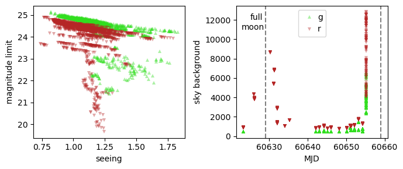

```python
fig, (ax1, ax2) = plt.subplots(1, 2, figsize=(7, 3))
ax2.axvline(60629, ls='dashed', color='grey')
ax2.axvline(60659, ls='dashed', color='grey')
ax2.text(60625.0, 12000, 'full')
ax2.text(60622.8, 11000, 'moon')
for filt in filter_names:
    fx = np.where(results['band'] == filt)[0]
    if len(fx) > 0:
        ax1.plot(results['seeing'][fx], results['magLim'][fx],
                 filter_symbols[filt], ms=5, mew=0, alpha=0.4,
                 color=filter_colors[filt], label=filt)
        ax2.plot(results['expMidptMJD'][fx], results['skyBg'][fx],
                 filter_symbols[filt], ms=5, mew=0, alpha=0.4,
                 color=filter_colors[filt], label=filt)
ax1.set_xlabel('seeing')
ax1.set_ylabel('magnitude limit')
ax2.set_xlabel('MJD')
ax2.set_ylabel('sky background')
ax2.legend(loc='upper center', handletextpad=0)
plt.tight_layout()
plt.show()
```

> **Figure 1:** At left, the magnitude limit of the image declines as the seeing increases. At right, the sky background as a function of time over the LSSTComCam campaign.

Clean up.

```python
job.delete()
del query, results
```

#### 3.2.2. Joinable tables

The `CcdVisit` table can be joined with `Visit` on column `visit`.

Like the `Visit` table, the `CcdVisit` table can be joined with the `Source`, `ForcedSource`, `DiaSource`, and `ForcedSourceOnDiaObject` tables on column `visit`.

No other TAP table has the `ccdVisitId` column.

##### Visit

For example, start with the same query as in Section 3.1.2. Add the selection of column `airmass` from the `Visit` table, but otherwise keep the query constraints the same.

```python
query = "SELECT cv.ccdVisitId, cv.visitId, cv.detector, " \
        "cv.ra, cv.dec, cv.band, cv.expMidptMJD, " \
        "cv.seeing, cv.skyBg, cv.magLim, v.airmass " \
        "FROM dp1.CcdVisit AS cv " \
        "JOIN dp1.Visit AS v ON cv.visitId = v.visit " \
        "WHERE CONTAINS(POINT('ICRS', cv.ra, cv.dec), " \
        "CIRCLE('ICRS', 53.13, -28.10, 3)) = 1 " \
        "AND (cv.band = 'r' OR cv.band = 'g') " \
        "ORDER BY cv.expMidptMJD ASC "
job = service.submit_job(query)
job.run()
job.wait(phases=['COMPLETED', 'ERROR'])
print('Job phase is', job.phase)
if job.phase == 'ERROR':
    job.raise_if_error()
```

```
Job phase is COMPLETED
```

```python
assert job.phase == 'COMPLETED'
results = job.fetch_result().to_table()
assert len(results) == 4203
print(len(results))
```

```
4203
```

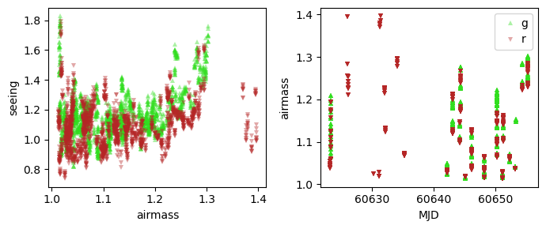

```python
fig, (ax1, ax2) = plt.subplots(1, 2, figsize=(7, 3))
for filt in filter_names:
    fx = np.where(results['band'] == filt)[0]
    if len(fx) > 0:
        ax1.plot(results['airmass'][fx], results['seeing'][fx],
                 filter_symbols[filt], ms=5, mew=0, alpha=0.4,
                 color=filter_colors[filt], label=filt)
        ax2.plot(results['expMidptMJD'][fx], results['airmass'][fx],
                 filter_symbols[filt], ms=5, mew=0, alpha=0.4,
                 color=filter_colors[filt], label=filt)
ax1.set_xlabel('airmass')
ax1.set_ylabel('seeing')
ax2.set_xlabel('MJD')
ax2.set_ylabel('airmass')
ax2.legend(loc='best', handletextpad=0)
plt.tight_layout()
plt.show()
```

### 3.2. Butler

The `visit_detector_table` is only available in full from the Butler (no subsetting), but for DP1 it will fit in a large container.

Show that the only dimension for the `visit_detector_table` is `instrument`.

```python
butler.get_dataset_type('visit_detector_table')
```

```
DatasetType('visit_detector_table', {instrument}, ArrowAstropy)
```

```python
butler.get_dataset_type('visit_detector_table').dimensions.required
```

```
{instrument}
```

Show that there is only one dataset references for the "LSSTComCam" `visit_detector_table`.

```python
dataset_refs = butler.query_datasets("visit_detector_table", instrument="LSSTComCam")
print(len(dataset_refs))
print(dataset_refs[0])
```

```
1
visit_detector_table@{instrument: 'LSSTComCam'} [sc=ArrowAstropy] (run=LSSTComCam/runs/DRP/DP1/v29_0_0/DM-50260/20250416T185152Z id=420c9a41-907e-4e16-8a66-e318422c49be)
```

Retrieve the entire `visit_detector_table`.

```python
visit_detector_table = butler.get(dataset_refs[0])
```

Confirm that the `visit_detector_table` has 16071 rows.

```python
assert len(visit_detector_table) == 16071
print(len(visit_detector_table))
```

```
16071
```

Option to display the table (automatically truncated).

```python
# visit_detector_table
```

Display the rows of the table for one visit.

```python
tx = np.where(visit_detector_table['visitId'] == 2024110800245)[0]
visit_detector_table[tx]
```

*Table length=9*

| detectorId int64 | visitId int64 | physical_filter str32 | band str32 | ra deg float64 | dec deg float64 | pixelScale arcsec / pix float32 | zenithDistance deg float32 | expTime s float32 | zeroPoint mag float32 | psfSigma pix float32 | skyBg adu float32 | skyNoise adu float32 | astromOffsetMean arcsec float32 | astromOffsetStd arcsec float32 | nPsfStar int32 | psfStarDeltaE1Median float32 | psfStarDeltaE2Median float32 | psfStarDeltaE1Scatter float32 | psfStarDeltaE2Scatter float32 | psfStarDeltaSizeMedian pix float32 | psfStarDeltaSizeScatter pix float32 | psfStarScaledDeltaSizeScatter float32 | psfTraceRadiusDelta pix float32 | psfApFluxDelta float32 | psfApCorrSigmaScaledDelta float32 | maxDistToNearestPsf pix float32 | effTime s float32 | effTimePsfSigmaScale float32 | effTimeSkyBgScale float32 | … |
| --- | --- | --- | --- | --- | --- | --- | --- | --- | --- | --- | --- | --- | --- | --- | --- | --- | --- | --- | --- | --- | --- | --- | --- | --- | --- | --- | --- | --- | --- | --- |
| 0 | 2024110800245 | i_06 | i | 53.00453551947407 | -28.190330812465483 | 0.20034255 | 15.811996 | 30.0 | 31.838995 | 1.8325734 | 1425.881 | 40.684032 | 0.013188731 | 0.0075904555 | 77 | -0.0017561167 | -0.00053596497 | 0.014050585 | 0.012365655 | -0.0008765209 | 0.01351533 | 0.0073382757 | 0.27481803 | 0.12636535 | 0.021924777 | 794.26764 | 21.713379 | 0.6789396 | 1.1138377 | … |
| 1 | 2024110800245 | i_06 | i | 53.064355266935024 | -27.961231391766976 | 0.2002798 | 15.809622 | 30.0 | 31.83873 | 1.7468716 | 1422.5039 | 37.339367 | 0.008955252 | 0.0046226964 | 88 | -0.0002264753 | 0.0003960058 | 0.012073228 | 0.009223385 | -0.00011816817 | 0.009787155 | 0.0055632405 | 0.12629928 | 0.12094698 | 0.01348997 | 628.4158 | 23.941256 | 0.7471915 | 1.116482 | … |
| 2 | 2024110800245 | i_06 | i | 53.12390882343404 | -27.731683579156535 | 0.20034228 | 15.810765 | 30.0 | 31.836647 | 1.78905 | 1418.3729 | 39.185055 | 0.008094447 | 0.003990346 | 99 | 0.0013976768 | -0.0001938045 | 0.011579151 | 0.013788158 | -0.003783381 | 0.019315107 | 0.010649642 | 0.1963391 | 0.05447564 | 0.014677442 | 682.1465 | 22.80446 | 0.71237546 | 1.1197337 | … |
| 3 | 2024110800245 | i_06 | i | 53.26469522335325 | -28.242507508599267 | 0.20027414 | 15.576916 | 30.0 | 31.837961 | 1.82284 | 1425.8518 | 39.428383 | 0.008271602 | 0.004680098 | 101 | 7.957034e-05 | -0.00013038516 | 0.009846868 | 0.009884624 | -0.0019776148 | 0.015945798 | 0.008746329 | 0.19495857 | 0.03981032 | 0.0026005514 | 654.0298 | 21.90459 | 0.6862097 | 1.1138605 | … |
| 4 | 2024110800245 | i_06 | i | 53.32375176154874 | -28.013505219153245 | 0.200218 | 15.574672 | 30.0 | 31.83915 | 1.7138672 | 1424.3231 | 39.147896 | 0.0077907415 | 0.0045658858 | 97 | -9.317696e-05 | 0.00066259503 | 0.010088383 | 0.009745861 | 0.0014382002 | 0.012073453 | 0.0069978684 | 0.074722014 | 0.020994948 | 0.015410803 | 767.8301 | 24.859604 | 0.7762463 | 1.1150559 | … |
| 5 | 2024110800245 | i_06 | i | 53.38273956426954 | -27.784217664042103 | 0.20027883 | 15.575785 | 30.0 | 31.838747 | 1.7853589 | 1414.5787 | 40.260956 | 0.0063703256 | 0.0036208716 | 84 | -0.0011746939 | -0.00051392615 | 0.0120537095 | 0.008244637 | -0.00039105458 | 0.0117064845 | 0.006516607 | 0.17354898 | 0.08796143 | 0.008903709 | 796.4788 | 23.049265 | 0.71532404 | 1.122737 | … |
| 6 | 2024110800245 | i_06 | i | 53.5246792145985 | -28.294803370278277 | 0.20035267 | 15.342082 | 30.0 | 31.8388 | 1.8442194 | 1428.1514 | 39.904015 | 0.011732553 | 0.007160589 | 104 | -0.00047815964 | -0.0011714646 | 0.011638308 | 0.010554459 | -0.0015049732 | 0.015615952 | 0.008536858 | 0.22199431 | 0.05017352 | 0.014885595 | 743.4191 | 21.398252 | 0.67039186 | 1.112067 | … |
| 7 | 2024110800245 | i_06 | i | 53.583628284352976 | -28.065367862820302 | 0.20027706 | 15.339507 | 30.0 | 31.840176 | 1.7520168 | 1415.0815 | 39.239273 | 0.0071751294 | 0.0044429163 | 101 | -0.0018707961 | -0.0017534588 | 0.010023365 | 0.012411433 | -0.00050531386 | 0.015835546 | 0.0089816665 | 0.15744267 | 0.073010385 | 0.01119243 | 700.81665 | 23.989433 | 0.7428094 | 1.1223382 | … |
| 8 | 2024110800245 | i_06 | i | 53.64216871041843 | -27.83604930238401 | 0.20035034 | 15.340555 | 30.0 | 31.838373 | 1.8212446 | 1417.9701 | 40.677723 | 0.008442235 | 0.0040146704 | 70 | 0.00043812394 | -0.0025645457 | 0.00977064 | 0.0133948205 | -0.00044736837 | 0.011746131 | 0.0064166808 | 0.25612888 | 0.049838874 | 0.017017128 | 948.7077 | 22.081709 | 0.6874124 | 1.1200519 | … |

#### 3.2.1. Visit images

The `CcdVisit` table's rows contain metadata for the corresponding `visit_image`.

Option to retrieve the `visit_image` for the first row of the table displayed above.

```python
# visit = visit_detector_table[tx[0]]['visitId']
# detector = visit_detector_table[tx[0]]['detectorId']

# visit_image = butler.get('visit_image',
#                          visit = visit,
#                          detector = detector)
```

```python
# del visit_image
```

Clean up.

```python
del dataset_refs, visit_detector_table, tx
```